# Introduction to R and RStudio

Mahbubul Majumder, PhD  
Sep 2, 2014

### What is R?

- Open source statistical programming language.
- A collaborative effort
  - many people contribute
  - to include a package first we need to install the package

```r
  install.packages("package-name")
  library("package-name")
```

### RStudio environment

- RStudio makes it convenient to use
- Everything is organized, at your finger tip
- Specially very convenient to create dynamic documents

### Most important R command

# ?

- Please use it and **read** the documentation
- Example: to learn about plot function

```r
? plot
```

- Commands are executed in line

### Modes of data in R

- numeric
- character
- logical
- factor
- ordered
- complex
- raw
- NULL

How do they work?

```r
x <- "5.42"
is.numeric(x)
```

```
[1] FALSE
```

```r
y <- as.numeric("5.44")
mode(y)
```

```
[1] "numeric"
```

### R data structures

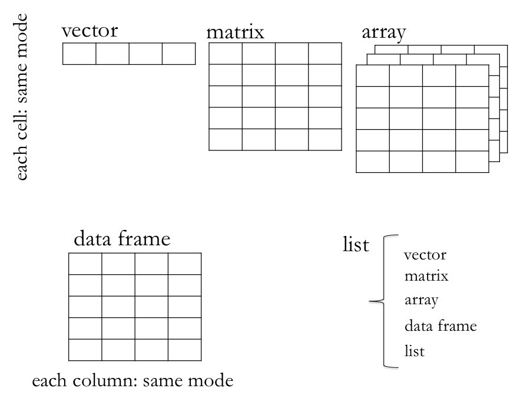

Notice the difference

```r
x <- c(1,2,3)
x
```

```
[1] 1 2 3
```

```r
y <- c(1,2,"3")
y
```

```
[1] "1" "2" "3"
```

```r
mode(y)
```

```
[1] "character"
```

### Get properties of data structures

- `mode()`
- `length(), nrow(), ncol(), dim()`
- `names() rownames() colnames ()`

```r
x <- matrix(1:12, ncol=3)
x
```

```
     [,1] [,2] [,3]
[1,]    1    5    9
[2,]    2    6   10
[3,]    3    7   11
[4,]    4    8   12
```

```r
dim(x)
```

```
[1] 4 3
```

### R objects

- OO programming
- Is everything an object or method or class?
- Assigning value to an object
  - assign average to a object called myValue

```r
myValue <- mean(1:20)
myValue
```

```
[1] 10.5
```

- equality operator `=` also works

```r
yourValue = mean(1:20)
yourValue
```

```
[1] 10.5
```

### Generating data

- Vectors `c(), seq(), rep(), 1:n, rnorm(), rpois()`

```r
x <- seq(1,2.5,by=.5)
x
```

```
[1] 1.0 1.5 2.0 2.5
```

```r
rnorm(mean=2,sd=3, n=3)
```

```
[1] 3.766 5.432 1.994
```

- Matrix

```r
y <- matrix(x,nrow=2)
y
```

```
     [,1] [,2]
[1,]  1.0  2.0
[2,]  1.5  2.5
```

- List

```r
z <- list(x, y)
z
```

```
[[1]]
[1] 1.0 1.5 2.0 2.5

[[2]]
     [,1] [,2]
[1,]  1.0  2.0
[2,]  1.5  2.5
```

- know the structure

```r
str(z)
```

```
List of 2
 $ : num [1:4] 1 1.5 2 2.5
 $ : num [1:2, 1:2] 1 1.5 2 2.5
```

### Combining data

`c(), rbind(), cbind(), data.frame ()`

```r
x <- seq(2, 6, by = 2)
c(x,0,20)
```

```
[1]  2  4  6  0 20
```

```r
rbind(x,y=1:3)
```

```
  [,1] [,2] [,3]
x    2    4    6
y    1    2    3
```

```r
zz <- cbind(x,y=1:3)
zz
```

```
     x y
[1,] 2 1
[2,] 4 2
[3,] 6 3
```

```r
z <- c("A",1,"B")
d <- data.frame(zz, z)
d
```

```
  x y z
1 2 1 A
2 4 2 1
3 6 3 B
```

```r
names(d)
```

```
[1] "x" "y" "z"
```

```r
str(d)
```

```
'data.frame':   3 obs. of  3 variables:
 $ x: num  2 4 6
 $ y: num  1 2 3
 $ z: Factor w/ 3 levels "1","A","B": 2 1 3
```

### R operators

- Simple math `+ - * /`
- More math `^ %/% %%`
- Compare `== < > <= >= !=`
- Logical `&& || & | !`

```r
9 %/% 4
```

```
[1] 2
```

```r
9 %% 4
```

```
[1] 1
```

```r
9==4
```

```
[1] FALSE
```

```r
! (9==5)
```

```
[1] TRUE
```

```r
(9==5) && (5==5)
```

```
[1] FALSE
```

```r
(9==5) | (5==5)
```

```
[1] TRUE
```

Quiz:  
What is the difference between `&` and `&&`

### User defined operator

- We can define our own operator
- Suppose we want to use `%!%` to obtain geometric mean of two numbers
- We define our operator as follows

```r
"%!%" <- function(x,y){
  res <- x*y
  if(res < 0) {
    cat("GM is undefined for given values")
    }else return(sqrt(res))
}
```

- now let us use our operator

```r
4%!%9
```

```
[1] 6
```

```r
4%!%(-9)
```

```
GM is undefined for given values
```

### Vectorized calculations

- Functions work on the whole structure
- Try not to use loops
- There may be a way not to use loop

```r
x <- rep(1:2,2)
x
```

```
[1] 1 2 1 2
```

```r
x+4
```

```
[1] 5 6 5 6
```

```r
sum(x^2)
```

```
[1] 10
```

```r
y <- matrix(1:9,ncol=3)
y
```

```
     [,1] [,2] [,3]
[1,]    1    4    7
[2,]    2    5    8
[3,]    3    6    9
```

```r
# elementwise operation
y/y
```

```
     [,1] [,2] [,3]
[1,]    1    1    1
[2,]    1    1    1
[3,]    1    1    1
```

Quiz:  
What would happen for `y/c(1,2,3)`

### Some statistical functions

- Summary functions:  
  `mean() median() quantile() sd()`
- Fitting model: `lm() glm() nlme() coef() anova()`
- Distribution:  
  `dbeta() dbinom() dcauchy() dchisq() dexp() dgamma() dnorm() dpois()`
- Use p for probability and r for random number. For example: `pbeta()` will compute beta probability and `rbeta()` will generate random number

```r
x <- rpois(n=5, lambda=2)
x
```

```
[1] 0 2 2 2 3
```

```r
mean(x)
```

```
[1] 1.8
```

```r
ppois(x, lambda=2)
```

```
[1] 0.1353 0.6767 0.6767 0.6767 0.8571
```

### Vector and matrix operations

```r
x <- matrix(1:12,ncol=3)
x
```

```
     [,1] [,2] [,3]
[1,]    1    5    9
[2,]    2    6   10
[3,]    3    7   11
[4,]    4    8   12
```

```r
colMeans(x)
```

```
[1]  2.5  6.5 10.5
```

- Transpose a matrix

```r
t(x)
```

```
     [,1] [,2] [,3] [,4]
[1,]    1    2    3    4
[2,]    5    6    7    8
[3,]    9   10   11   12
```

- Matrix multiplication

```r
y <- rep(1,4)
y
```

```
[1] 1 1 1 1
```

```r
y %*% x
```

```
     [,1] [,2] [,3]
[1,]   10   26   42
```

```r
diag(x)
```

```
[1]  1  6 11
```

- More functions `solve() eigen()` also `ginv()` which requires MASS package

### Missing data

- Missing data are reported as NA
  - To check if there is any missing data

```r
x <- c(1,4,6,NA)
is.na(x)
```

```
[1] FALSE FALSE FALSE  TRUE
```

- Functions may return NA

```r
mean(x)
```

```
[1] NA
```

```r
mean(x, na.rm=T)
```

```
[1] 3.667
```

### Working with NA

- Functions related to NA `is.na() na.action() na.omit()`
- Use inside other function `na.rm = T or F`

```r
x <-  c(3,6,9,NA,3)
x/3
```

```
[1]  1  2  3 NA  1
```

```r
sum(x, na.rm=T)
```

```
[1] 21
```

```r
y <- na.omit(x)
sum(y)
```

```
[1] 21
```

### User defined functions in R

```r
get_square <- function(x){
  if(x>100)
    return("Big number") else
      return(x^2)
}

get_square(5)
```

```
[1] 25
```

```r
get_square(500)
```

```
[1] "Big number"
```

```r
get_square(c(25,200)) # what is wrong here?
```

```
[1]   625 40000
```

### Recursive functions

```r
foo <- function(x){
  print(x)
  if(x>1) foo(x-1)
}
```

foo(10) = ?

- Recursion function vs stack overflow
- Should be avoided for large computation

```r
moo <- function(x){
  if(x>1) moo(x-1)
  print(x)
}
```

moo(10) = ?

### Loops and controls in R

- R has powerful functions and if you use them properly you don't need loop
- If you use loop you may cost computing time
- But if you have to use it, go ahead
- Quiz:  
  What is the output of this loop?

```r
for (i in c("A","B", "C")){
  if(i > "B") print(i)
}
```

What is wrong here?

```r
if(4==5) print("A")
  else print("B")
```

- Control flow

```r
if(cond) expr
if(cond) cons.expr  else
  alt.expr

for(var in seq) expr
while(cond) expr
repeat expr
break
next
```

### Getting data onto R

- `read.table() scan() load()`
- Reading data directly from the web

```r
url <- "http://mahbub.stat.iastate.edu/ecg_fractal/ecg_cvp.csv"
dat <- read.table(url, header=T, sep=",")
head(dat)
```

```
     tm    ECG   CVP
1 0.000 -0.140 4.781
2 0.003 -0.153 4.781
3 0.006 -0.151 4.831
4 0.008 -0.137 4.831
5 0.011 -0.131 4.880
6 0.014 -0.136 4.930
```

- more functions `read.csv() readLines()`
- `? read.table`

### First steps to explore data

As soon as you read a data object

- `head(), tail()`
- `summary(), str()`
- `plot()`
- Example: built in data frame trees

```r
head(trees)
```

```
  Girth Height Volume
1   8.3     70   10.3
2   8.6     65   10.3
3   8.8     63   10.2
4  10.5     72   16.4
5  10.7     81   18.8
6  10.8     83   19.7
```

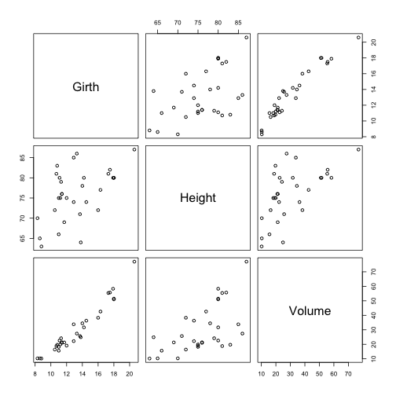

```r
plot(trees)
```

### Case study: A quick cluster analysis

- Default database mtcars has 32 records and 11 variables. The variables are mpg, cyl, disp, hp, drat, wt, qsec, vs, am, gear, carb
- Clustering the cars

```r
d <- dist(as.matrix(mtcars))
hc <- hclust(d)
groups <- cutree(hc, k = 6)
```

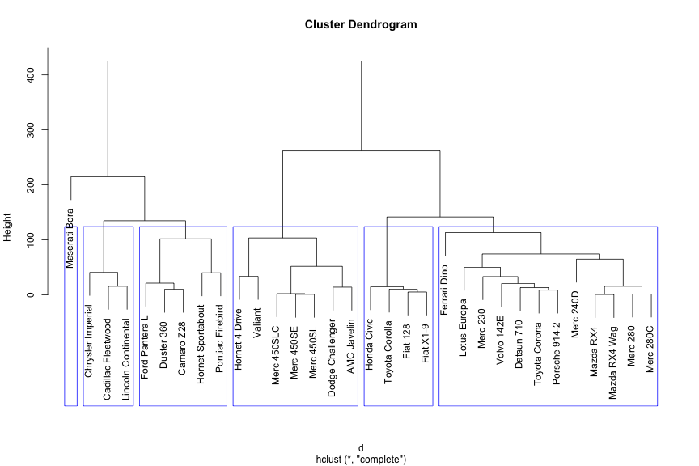

```r
plot(hc)
rect.hclust(hc,  border="blue",k=6)
```

### Reading assignments and resources

- An Introduction to R  
  http://cran.r-project.org/doc/manuals/R-intro.pdf
- Manual for R Data Import/Export. It describes the import and export facilities available either in R itself or via packages which are available from CRAN http://cran.r-project.org/
- Getting help with R, a very helpful documentation provided by RStudio. It also gives the links of nice resources to learn about R. https://support.rstudio.com/hc/en-us/articles/200552336-Getting-Help-with-R
- Keep this reference card all the time with you. http://cran.r-project.org/doc/contrib/Short-refcard.pdf